# GWAS-по-adeno

Для начала то, что необходимо всегда помнить. Принципы case-control GWAS:

- case и control взяты из одной популяции;
- case отобраны, ошибочные case будут значительно снижать статистическую мощность исследования;
- генетические и эпидемиологические данные cases и controls собраны одинаково;
- отобранные controls должны иметь риск развития фенотипа, например, нельзя использовать женщин при изучении мужских фенотипов.

Из входных данных было загружено 81271745 маркеров и 2504 индивидуумов.

На вход было подано 498 фенотипа, из которых 117 кейсов и 381 контролей.

Затем к выборке были применены следующие фильтры:

Фильтры

| Параметр | Пороговое значение | Исключено | Описание |
| --- | --- | --- | --- |
| –mind | 0.1 | 0 | Исключить образцы с низким Call Rate |
| –geno | 0.05 | 42170 | Исключить SNP с низким Call Rate |
| –hwe | 0.001 | 145702 | Исключить маркеры, не прошедшие тест Харди-Вайнберга |
| –maf | 0.01 | 71339961 | Исключить SNP с низким MAF |
| –me | 1 1 |  | Занулить генотипы, содержащие менделевские ошибки |

Также было исключено 0 родственников на основе родословных (–filter-founders).

После фильтрации осталось **9743912** маркеров и 498 человек, из которых **117** кейсов и **381** контролей.

### Manhattan plot:

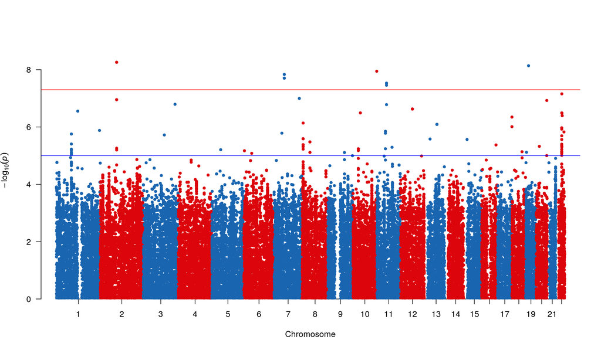

В анализе использовался мягкий порог на MAF. Рекомендуем использовать фильтр C_U $\geq$ 10 и C_A $\geq$ 10.

Первые 1000 строк результатов теста на ассоциацию:

| Imputed | DR2 | RS | SNP | Region | Gene | Minor allele | Major allele | MAF | Control allele count (C_U) | Case allele count (C_A) | Control allele freq (F_U) | Case allele freq (F_A) | Control Missing Rate (F_MISS_U) | Case Missing Rate (F_MISS_A) | P-value | SE | OR | OR 95% conf. int. |
| --- | --- | --- | --- | --- | --- | --- | --- | --- | --- | --- | --- | --- | --- | --- | --- | --- | --- | --- |
|  |  |  | rs371395170 |  |  | C | A | 0.06818 | 26 | 40 | 0.03542 | 0.1709 | 0 | 0 | 5.525e-09 | 0.2769 | 5.026 | (2.921, 8.648) |
|  |  |  | rs377724030 |  |  | T | G | 0.06818 | 26 | 40 | 0.03542 | 0.1709 | 0 | 0 | 5.525e-09 | 0.2769 | 5.026 | (2.921, 8.648) |
|  |  |  | rs563244025 |  |  | AAT | A | 0.08161 | 37 | 42 | 0.05041 | 0.1795 | 0 | 0 | 7.292e-09 | 0.2635 | 4.591 | (2.739, 7.695) |
|  |  |  | rs566292442 |  |  | G | GT | 0.06095 | 25 | 34 | 0.03406 | 0.1453 | 0 | 0 | 1.135e-08 | 0.2973 | 5.46 | (3.049, 9.778) |
|  |  |  | rs201271733 |  |  | C | G | 0.1498 | 85 | 60 | 0.1158 | 0.2564 | 0 | 0 | 1.465e-08 | 0.2309 | 3.7 | (2.353, 5.818) |
|  |  |  | rs574142535 |  |  | A | G | 0.1498 | 85 | 60 | 0.1158 | 0.2564 | 0 | 0 | 1.465e-08 | 0.2309 | 3.7 | (2.353, 5.818) |
|  |  |  | rs369763792 |  |  | C | T | 0.157 | 90 | 62 | 0.1226 | 0.265 | 0 | 0 | 1.975e-08 | 0.2302 | 3.641 | (2.319, 5.717) |
|  |  |  | rs542550542 |  |  | C | T | 0.157 | 90 | 62 | 0.1226 | 0.265 | 0 | 0 | 1.975e-08 | 0.2302 | 3.641 | (2.319, 5.717) |
|  |  |  | rs562923350 |  |  | T | C | 0.157 | 90 | 62 | 0.1226 | 0.265 | 0 | 0 | 1.975e-08 | 0.2302 | 3.641 | (2.319, 5.717) |
|  |  |  | esv3626410 |  |  | &lt;CN0&gt; | G | 0.03409 | 11 | 22 | 0.01499 | 0.09402 | 0 | 0 | 2.959e-08 | 0.4143 | 9.94 | (4.413, 22.39) |

[output cut: 990 more lines]

Наши клиенты представляют собой гетерогенную популяцию. Убедимся в этом с помощью PCA (`plink`):

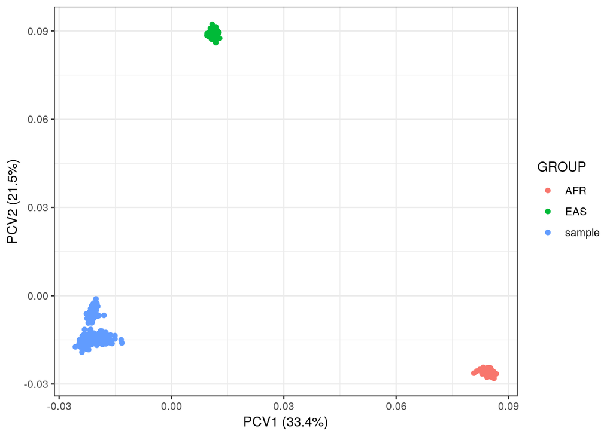

Посмотрим на структуру популяции после удаления выбросов (`smartpca`):

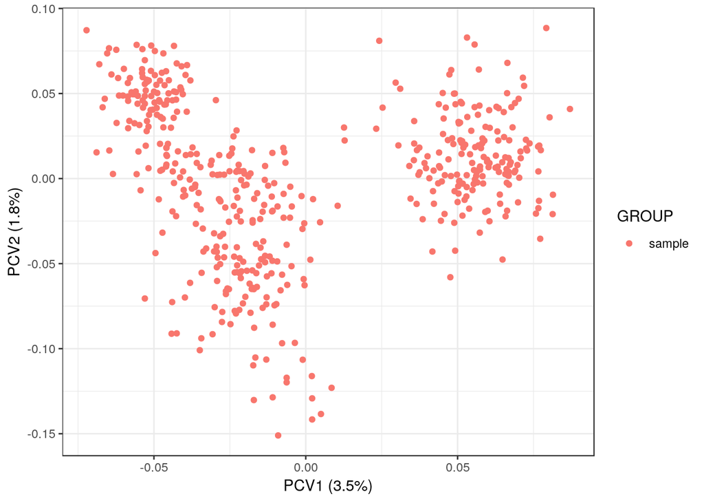

Были удалены следующие образцы:

| N | Prob | Pop |
| --- | --- | --- |
| 1 | HG00116 | Control |
| 2 | HG00120 | Control |
| 3 | NA11931 | Control |
| 4 | NA11932 | Control |
| 5 | NA11933 | Control |
| 6 | NA12155 | Control |
| 7 | NA12342 | Control |
| 8 | NA12383 | Control |
| 9 | NA12760 | Control |
| 10 | NA12830 | Control |
| 11 | NA12005 | Control |
| 12 | NA12414 | Control |
| 13 | NA12878 | Control |
| 14 | NA06985 | Control |

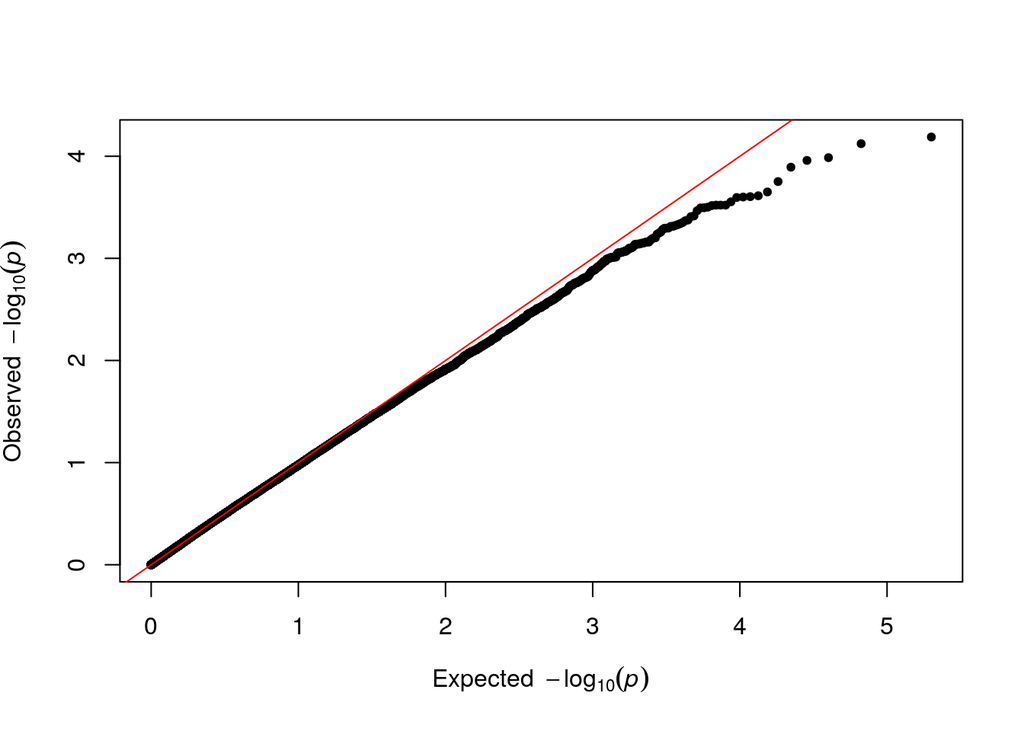

Гистограммы для каждого из предикторов:

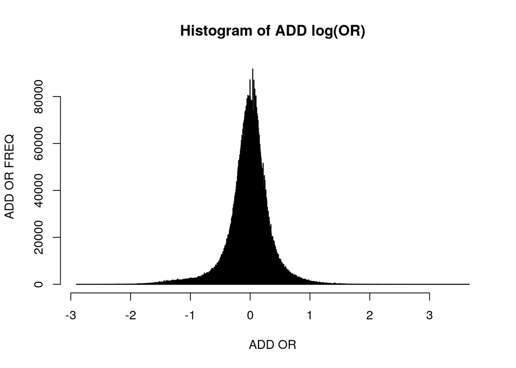

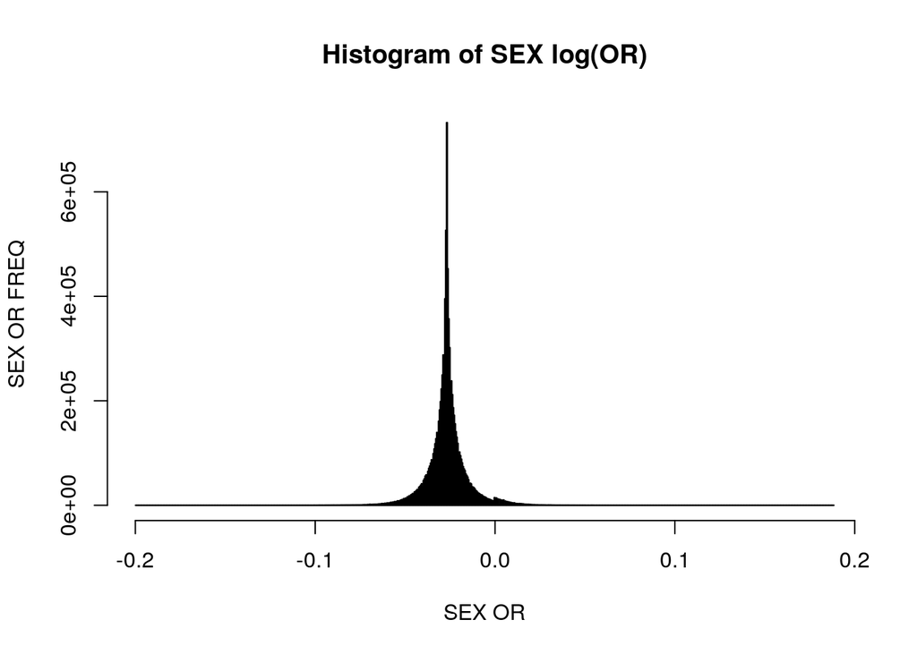

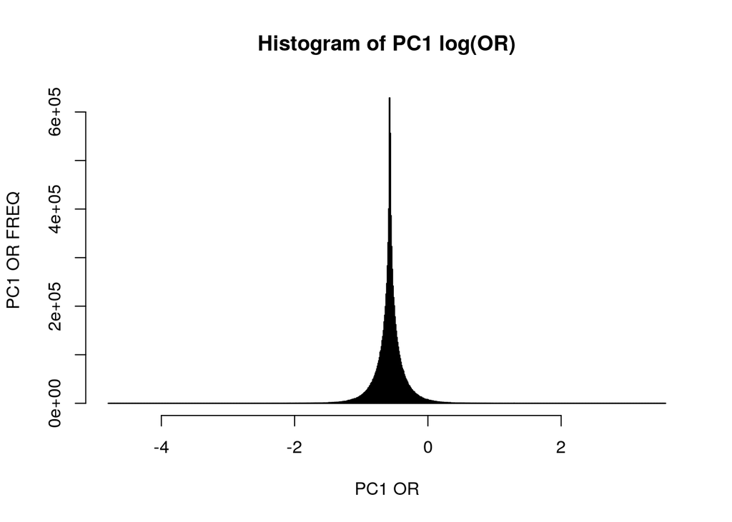

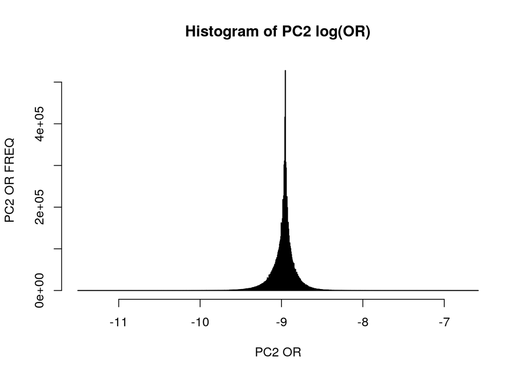

Пайплайн был разработан на основе следующих публикаций:

- Anderson, Carl A et al. Data quality control in genetic case-control association studies. Nature protocols vol. 5, 9 (2010): 1564-73.
- Pearson TA, Manolio TA. How to Interpret a Genome-wide Association Study. JAMA. 2008; 299(11): 1335-1344.

Дата генерации отчета: Thu May 23 19:07:48 2019